# Senthooran Yogeswaran

```r
library(tidyverse)
```

```r
library(devtools)
install_github("nxskok/smmr")
```

```
Skipping install of 'smmr' from a github remote, the SHA1 (b5b23fca) has not changed since last install.
  Use `force = TRUE` to force installation
```

```r
library(smmr)
```

#1a We read the CSV file from a url

```r
my_url <- "http://ritsokiguess.site/STAC32/pop.csv"
pop <- read_csv(my_url)
pop
```

[output not shown]

#1b) We create a histogram since there is only one quantitative value

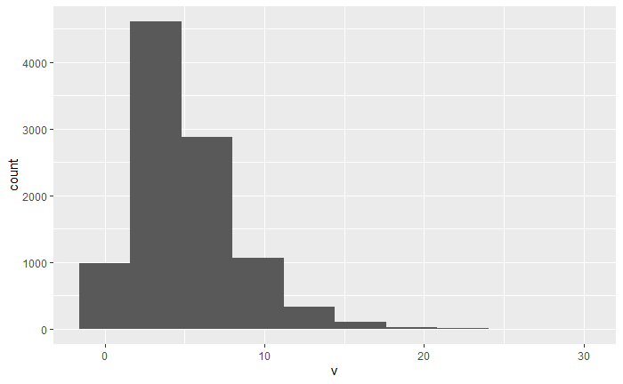

```r
ggplot(pop, aes(x = v)) + geom_histogram(bins = 10)
```

#The histogram seems to be right skewed

#1c)

```r
pop %>% summarise(m=mean(v),s=sd(v))
```

| m | s |
| --- | --- |
| 5 | 3.168179 |

#the mean is 5 and the SD is around 3.17

```r
rerun(1000, rnorm(10, 5, 3.168179)) %>%
  map( ~ t.test(., mu = 4)) %>%
  map_dbl("p.value") %>%
  enframe(value="pvals") %>%
  count(pvals <= 0.05)
```

| pvals <= 0.05 | n |
| --- | --- |
| FALSE | 854 |
| TRUE | 146 |

#1d) We fail to reject the null since it is roughly 85% FALSE

```r
rerun(1000, rnorm(50, 5, 3.168179)) %>%
  map( ~ t.test(., mu = 4)) %>%
  map_dbl("p.value") %>%
  enframe(value="pvals") %>%
  count(pvals <= 0.05)
```

|  | pvals <= 0.05 | n |
| --- | --- | --- |
| 1 | FALSE | 405 |
| 2 | TRUE | 595 |

#A larger sample size would imply our sample mean will get close #to the true mean and reflecting the population

1e)

```r
rerun(1000, rnorm(50, 5, 3.168179)) %>%
  map( ~ t.test(., mu = 5)) %>%
  map_dbl("p.value") %>%
  enframe(value="pvals") %>%
  count(pvals <= 0.05)
```

| pvals <= 0.05 | n |
| --- | --- |
| FALSE | 958 |
| TRUE | 42 |

# We read the csv file from an url

2a)

```r
my_url <- "http://ritsokiguess.site/STAC33/protein.txt"
prot <- read_csv(my_url)
prot
```

| protein |
| --- |
| 5.1 |
| 4.2 |
| 6.1 |
| 5.1 |
| 5.7 |
| 5.5 |
| 4.9 |
| 6.1 |
| 6.1 |
| 5.8 |

[output cut: 10 more lines]

#We create a histogram since there is only one quantitative value 2b)

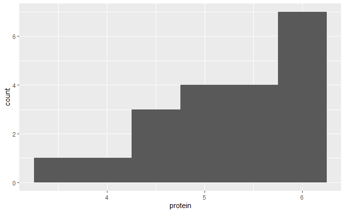

```r
ggplot(prot, aes(x = protein)) + geom_histogram(bins =6)
```

#The following histogram is left skewed. Using less bins here will show it as #using more is not needed due to the dataframe consisting of less variables

2C) #Average in this case means any measure of centre. A sign test measures the #median which is the centre value of the data while the t.test measures the #mean. The graph here is left skewed which means outlier values will affect #the mean thus making the median a better choice

2D)

```r
sign_test(prot, protein, 6)
```

```
$above_below
below above
   15     5

$p_values
```

| alternative | p_value |
| --- | --- |
| lower | 0.02069473 |
| upper | 0.99409103 |
| two-sided | 0.04138947 |

```
NA
```

#p value = 0.04 #Since our p value is less than 0.05 we can reject the null hypothesis #and choose the alternative. We can conclude the meals advertising as #containing “6 ounces of protein per package” false. Therefore the #consumer organization is right in there assessment that it is not #accurate

2E) #The histogram tells us that the p value is going to be small due to the #skewness in the graph. The graph is left skewed meaning the median will #not consist of 6 ounces of protein per package. The graph further tells #us that only the count of 6 ounces of protein per package has the highest #value for it but other values do exist!

2F)

```r
ci_median(prot, protein, conf.level=0.90)
```

```
[1] 4.905273 5.793750
```